# Homework #4

Nathaniel Wigdahl & Aidan Bergstein

2/16/2022

```r
choco <- read.csv("https://ds202-at-isu.github.io/labs/data/choco.csv")
head(choco)
```

```
##    Company Specific.Bean.Origin  REF Review.Date Cocoa.Pct Company.Location
## 1 A. Morin          Agua Grande 1876        2016        63           France
## 2 A. Morin                Kpime 1676        2015        70           France
## 3 A. Morin               Panama 1011        2013        70           France
## 4 A. Morin           Madagascar 1011        2013        70           France
## 5 A. Morin               Brazil 1011        2013        70           France
## 6 A. Morin             Equateur 1011        2013        70           France
##   Rating Bean.Type Broad.Bean.Origin
## 1   3.75                    Sao Tome
## 2   2.75                        Togo
## 3   2.75                      Panama
## 4   3.00   Criollo        Madagascar
## 5   3.25                      Brazil
## 6   3.75                     Ecuador
```

### Question Set 1

1. What is the overall number of chocolate bars rated?

```r
count(choco)
```

```
##      n
## 1 1852
```

2. How does the number of ratings depend on the year? Draw a bar chart of the number of reports.

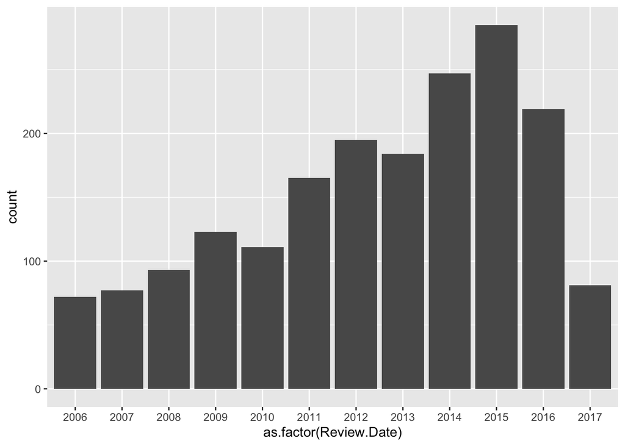

```r
choco %>% ggplot(aes(x = as.factor(Review.Date))) + geom_bar()
```

### Question Set 2

For each of the questions below provide at least one graphic as a basis for your answer.

1. How are ratings distributed? Draw a histogram of ratings and describe it. Don’t forget to mention outliers, if there are any.

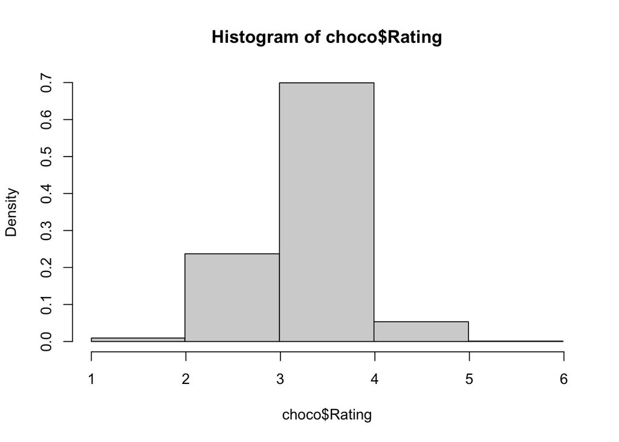

```r
breaks =c(1, 1.99, 2.99, 3.99, 4.99, 5.99);
hist(choco$Rating, breaks = breaks)
```

This histogram is pretty chunky, let’s make it more granular

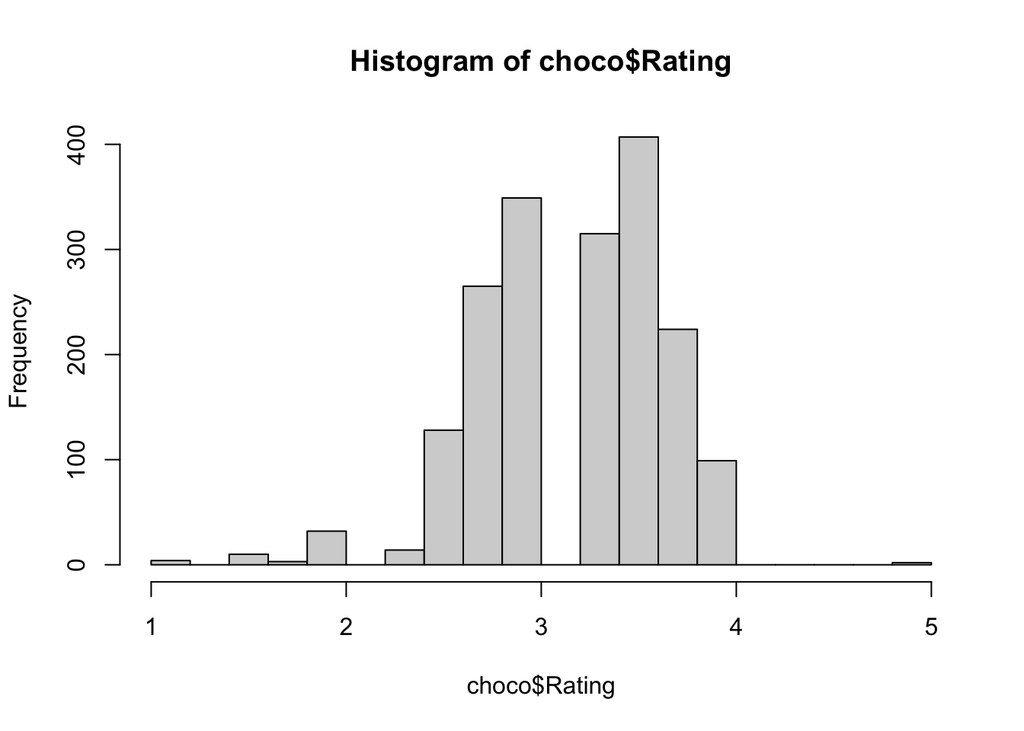

```r
hist(choco$Rating, breaks = 17)
```

Here we can see that the ratings are almost entirely distributed between 2 and 4, with a slight left skew towards one. There are also some outliers at 5. I wonder how many?

```r
count(filter(choco, Rating > 4))
```

```
##   n
## 1 2
```

So there are only two ratings above 4, which if we looks closer are both ratings of 5.

2.Do ratings depend on the cocoa percentage of a chocolate bar?

We’ll use a scatterplot to examine the relation between Rating and Cocoa.Pct

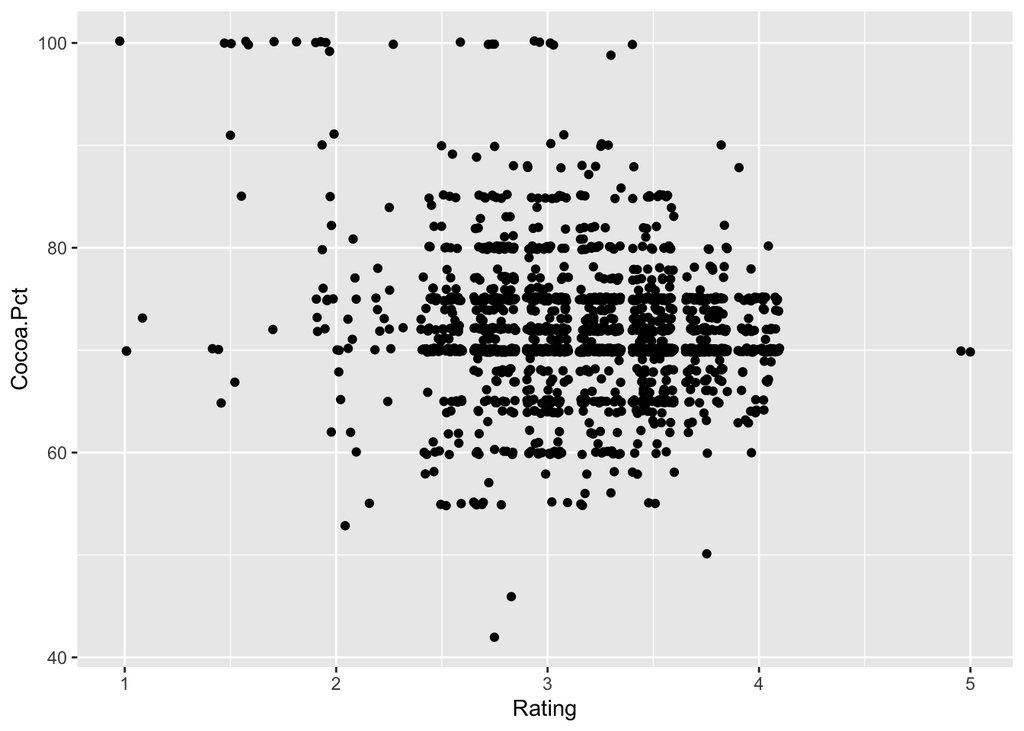

```r
ggplot(choco, aes(x=Rating, y=Cocoa.Pct))+geom_jitter()
```

Here we can see no linear relationship between the cocoa percentage and the rating. In fact the two highest rated chocolates have a similar percentage as three of the lowest rated chocolates.

### Your Question

1. Discuss a question you want to investigate.
2. Answer this question by graphs.
3. Conclusions.

### Submission

In Canvas, submit an RMarkdown file with: 1. the names of all team members that worked on the document; 2. a link to the github repo you were working in; 3. code and answers to all of the questions; 4. the question you want to investigate with its answers and conclusions; 5. one paragraph commenting on the workflow; 6. a html or pdf file of the final output.